# USE R!

Introducción al Lenguaje R

Santiago Benitez-Vieyra

# ¿Por qué un lenguaje?

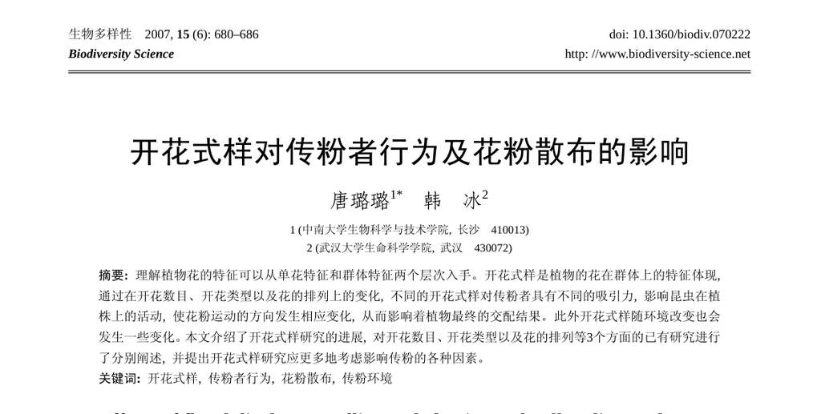

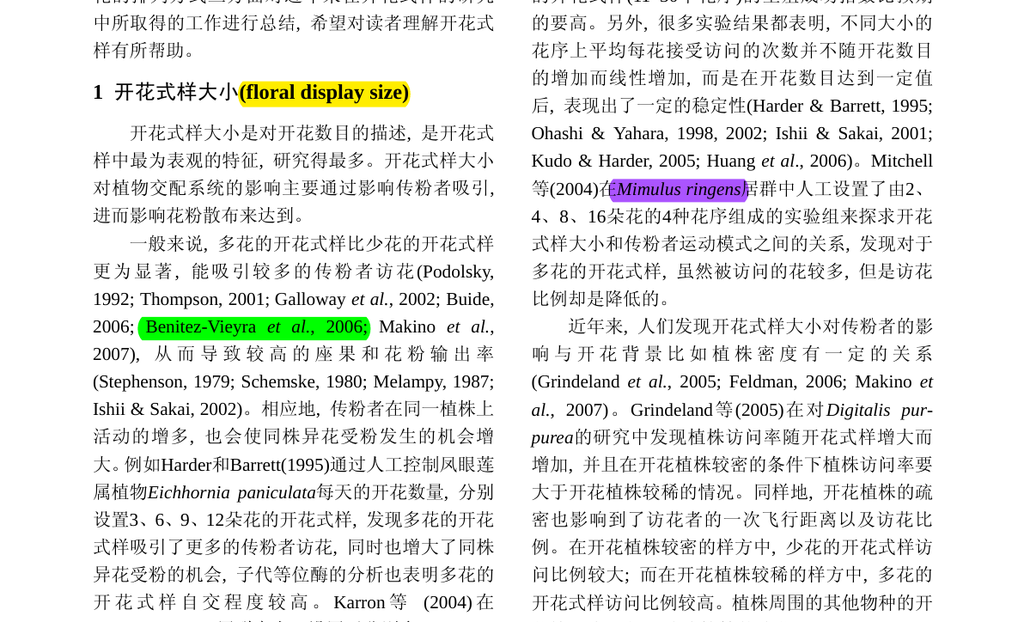

# Resumen:

- Hay conceptos confusos en chino
- Entre latín y chino, latín.

> R es un lenguaje para comunicar análisis estadísticos y gráficos y también para programar nuevos métodos.

# Lenguaje para construir una rutina de análisis.

```r
library(vegan)
dat <- read.table("/home/santiago/mandevilla.txt", header = TRUE)

## multidimensional scaling
m1 <- metaMDS(dat2, dist = "bray", k = 2)
m1

## figura
plot(m1, "sites", type = "n")
points(m1$points[,1],
       m1$points[,2],
       pch = c(rep(1, 4), rep(19, 4), rep(19, 3),
               rep(1, 5), rep(19, 4), rep(1, 4)),
       col = c(rep("blue4", 4), rep("blue4", 4), rep("red4", 3),
      rep("red4", 5), rep("green4", 4), rep("green4", 4)))

## agregar compuestos
points(m1, "species", pch = 2, cex = 0.7)
## agregar nombres de compuestos
text(m1$species[, 1], m1$species[, 2] - 0.1, colnames(dat2), cex = 0.6)

## anosim
tipo <- as.factor(c(rep("hib", 8), rep("lax", 8), rep("pen", 8)))
a1 <- anosim(dat = dat2, grouping = tipo, distance = "bray", permutations = 9999)
summary(a1)
perm <- permustats(a1)
densityplot(perm)
plot(a1)
```

# Escribir cartas.

Hi!  
I’m trying to use the map.overlap function of the R package phytools to compute the fraction of stochastic character mapping that is shared by two trees. But the function map.overlap does not accept my two stochastic character mappings. I did

```r
pollinator.map <- make.simmap(tree, pol, model="ER")
flower.trait.map <- make.simmap(tree, flower, model="ER")
class(flower.trait.map) <- "phylo"
class(pollinator.map) <- "phylo"
overlap.pol.flower <- map.overlap(pollinator.map, flower.trait.map)
```

But get this error message..

```r
Error in tabulate(phy$edge[, 1]) : 'bin' must be numeric or a factor*
```

# Responder Cartas.

Hi Marina.  
Your problem is that the trees returned by make.simmap with nsim>1 are an object of class “multiPhylo”. I’m guessing that the first time you ran this you encountered the error:

```r
Error in is.rooted(target) : object "phy" is not of class "phylo"
```

This cannot be resolved by just changing the class attribute of your object. Instead, you can iterate the function over a set of trees. For instance, you can use:

```r
overlap<-sapply(flower.trait.map,function(x,y)
  sapply(y,map.overlap,x),y=pollinator.map)
```

Which will give you a matrix of pairwise overlaps between map trees. Let us know if this is helpful. All the best, Liam

### Guardar las instrucciones de un gráfico.

```r
library(hdrcde)
x <- c(rnorm(200,0,1),rnorm(200,4,1))
y <- c(rnorm(200,0,1),rnorm(200,4,1))
par(mfrow=c(1,2))
plot(x,y, pch= "+", cex=.5)
hdr.boxplot.2d(x,y)
```

### Guardar las instrucciones de un gráfico.

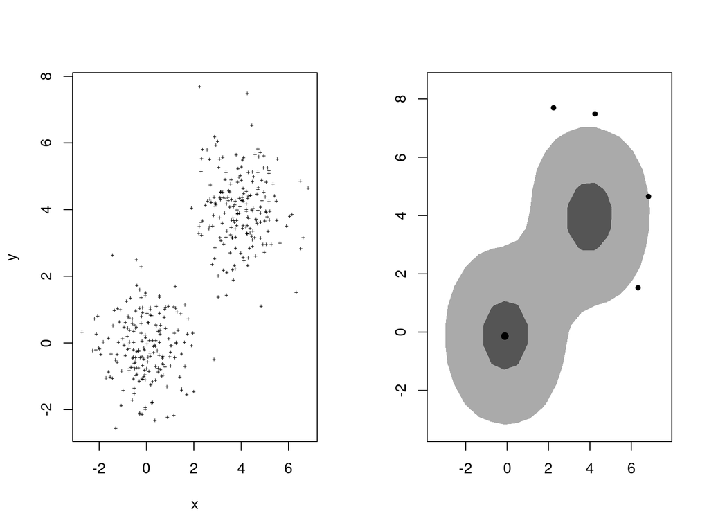

# Publicar la rutina de análisis.

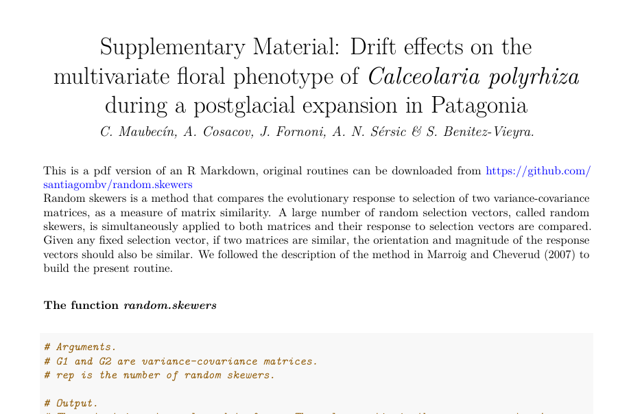

# Publicar un paquete.

[figure not shown]

# Publicar un paquete.

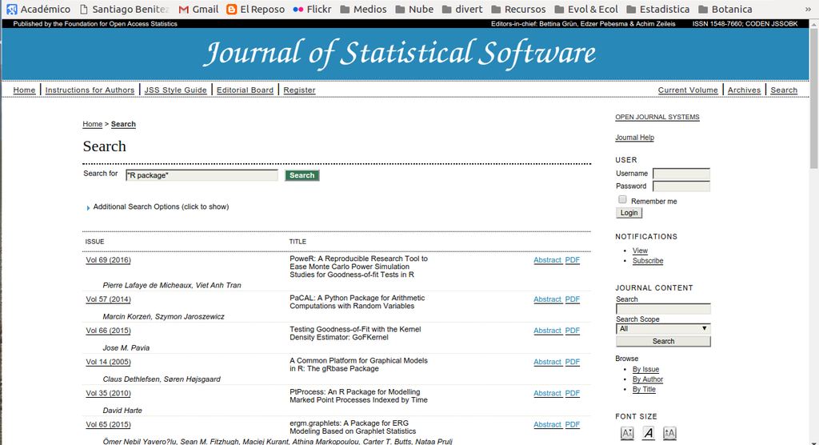

# Escribir libros…

[figure not shown]

# Usted puede usar R para que su investigación sea REPRODUCIBLE

- Métodos cuidadosamente descriptos
- Datos de libre disponibilidad
- Análisis estadístico reproducible

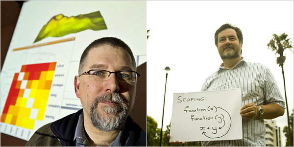

Ross Ihaka y Robert Gentleman

# R Core Team

Douglas Bates (USA), Roger Bivand (Norway), John Chambers (USA), Peter Dalgaard (Denmark) Dirk Eddelbuettel (USA), John Fox (Canada), Robert Gentleman (USA), Bettina Grün (Austria), Frank Harrell (USA), Kurt Hornik (Austria), Torsten Hothorn (Switzerland), Stefano Iacus (Italy), Ross Ihaka (New Zealand), Michael Lawrence (USA), Friedrich Leisch (Austria), Uwe Ligges (Germany), Thomas Lumley (USA, New Zealand), Martin Mächler (Switzerland), Martin Morgan (USA), Duncan Murdoch (Canada), Paul Murrell (New Zealand), Martyn Plummer (France), Brian Ripley (UK), Deepayan Sarkar (India), Marc Schwartz (USA), Duncan Temple Lang (USA), Luke Tierney (USA), Heather Turner (UK), Simon Urbanek (Germany, USA), Bill Venables (Australia), Hadley Wickham (USA), Achim Zeileis (Austria).

The R Journal https://journal.r-project.org/

[figure not shown]

# Paquetes

[figure not shown]

# Repos

[figure not shown]

# CRAN

[figure not shown]

# ¿Dónde buscar?

- [R Site Search](http://finzi.psych.upenn.edu/search.html)
- [R Seek](http://rseek.org/)
- [Stackoverflow](http://stackoverflow.com/)
- [Nabble](http://r.789695.n4.nabble.com/)
- [CRAN Task Views](https://cran.r-project.org/web/views/)
- [R Bloggers](http://www.r-bloggers.com/)
- [Quick R](http://www.statmethods.net/)
- Google…

# ¿Por qué usar R?

- Es el software más abarcativo.
- Más de 10000 paquetes específicos.
- Excelentes posibilidades gráficas.
- Comunidad de usuarios y programadores para consultar
- Lenguaje abierto.
- Adquirir habilidades de programación.
- Es libre y gratuito, pude ser copiado, distribuido y modificado a voluntad.

[figure not shown]

# Cómo no desanimarse…

- Probablemente el primer mensaje que recibas de R al usarlo sea: Error: object ‘x’ not found.
- La curva de aprendizaje de R es empinada.
- Instalar R y obligarse a usarlo, aunque sea para calcular una media.
- Familiarizarse con los archivos de ayuda de R.
- Tratar de conocer los diferentes tipos de objetos en R.
- Escribir tus rutinas en archivos separados (si sólo se escriben en la consola se pierden, en general, al cerrar el programa).
- Incorporar anotaciones a las rutinas.
- Tratar de escribir funciones.

# Interfaces Gráficas de Usuario (GUI).

> El lenguaje R y el software donde lo visualizamos son dos cosas diferentes.
- RGUI (Windows)
- [R Commander (R para seres humanos)](http://socserv.mcmaster.ca/jfox/Misc/Rcmdr/)
- [R Studio](https://www.rstudio.com/)
- [JGR (Java GUI for R)](http://rforge.net/JGR/)

# Objetivos del curso.

- Adquirir destreza en el uso del lenguaje R para su uso en estadística básica y gráficos, así como nociones de programación.
- Desarrollar una visión global de una amplia clase de modelos estadísticos.
- Adquirir destreza en la interpretación de análisis estadísticos y gráficos presentados en trabajos científicos.

# Contenidos del curso.

- Funciones básicas de R (creación de objetos, ingreso de datos, análisis básicos). Análisis gráfico. Modelos Lineales. Training and Test. Selección de variables, selección de modelos y regularización. Construcción de rutinas. Introducción a R Markdown.
- Manejo de gráficos básicos: Comandos gráficos de alto y bajo nivel, exportación de gráficos. Elección del gráfico adecuado para representar un análisis. Introducción a los paquetes lattice, y ggplot2.
- Discusión de trabajos: cómo presentar los resultados.
- Introducción a la programación: Construcción de funciones, rutinas, bucles, funciones condicionales y simulación de datos.
- Métodos de remuestreo y randomizaciones. Bootstrap

**Trabajo Final: Construcción de una rutina de resolución de problemas estadísticos y gráficos. Entrega de un informe.**